# *RMeDPower2*: helping design and analyses of data from repeated measures experiments

Reuben Thomas, Min-Gyoung Shin, Naufa Amirani, Stephanie Lam, Noura Al Bistami, Edward Vertudes, Krishna Raja, Julia A. Kaye and Steven Finkbeiner *Gladstone Institutes, San Francisco, CA, USA* Correspondence: `reuben.thomas@gladstone.ucsf.edu`

Abstract

Biomedical research very often involves data generated from repeated measures experiments. RMeDPower2 is an R package that provides complete functionality to analyse data coming from repeated measures experiments, i.e., where one has repeated measures from the same biological/independent units or samples. RMeDPower2 helps test the modeling assumptions one makes, identify outlier observations, outlier units at different levels of the design, estimates statistical power or perform sample size calculations, estimate parameters of interest and also to visualize the association being tested. The functionality is limited to testing associations of one predictor (continuous or categorical, e.g., disease status or brain pathology) along with one another covariate (e.g., gender status) in the context of hierarchical or crossed experimental designs. This vignette illustrates the use of this package in multiple contexts relevant to biomedical research.

RMeDPower2 defines the experimental design for the data, probability model of the data generating distribution and necessary parameters required for sample size calculation using convenient S4 class objects. It uses these objects in one framework that brings together the functionality implemented in multiple R packages - lme4 (implementation of linear mixed effects models), influence.ME (identification of outlier units), EnvStats (identification of outlier observations), DHARMa (testing of modeling assumptions for non-normal distributions), simr (sample-size calculations) and tidyverse (data manipulation and visualization).

# 1 Getting started

## 1.1 Installing `RMeDPower2`

`RMeDPower2` can be installed using the following commands

```r
install.packages("devtools")
library(devtools)
install_github('gladstone-institutes/RMeDPower2', build_vignettes=TRUE, force = TRUE)
```

## 1.2 Quick tutorial

The workflow can be accomplished in 5 main steps as described in the sections below (1.2.1-.2.5).

### 1.2.1 Load libraries and read input data

The first step is to load RMeDPower2 and read-in the input data as a data frame. This is accomplished by the following commands:

```r
suppressPackageStartupMessages(library(RMeDPower2))
suppressPackageStartupMessages(library(ggplot2))
suppressPackageStartupMessages(library(dplyr))
suppressPackageStartupMessages(library(magrittr))
options(warn = -1)
data <- plate_assay_pilot_data
```

Example data has experiment, line as experience columns, classification as the condition column, and cell size as the response column.

```r
knitr::kable(data[1:5,] )
```

| experiment | line | classification | cell_size1 | cell_size2 | cell_size3 | cell_size4 | cell_size5 | cell_size6 |
| --- | --- | --- | --- | --- | --- | --- | --- | --- |
| experiment1 | cellline1 | 0 | 353.8401 | 353.8401 | 353.8401 | 353.8401 | 353.8401 | 353.8401 |
| experiment1 | cellline1 | 0 | 350.7909 | 350.7909 | 350.7909 | 350.7909 | 350.7909 | 350.7909 |
| experiment1 | cellline1 | 0 | 327.9338 | 327.9338 | 327.9338 | 327.9338 | 327.9338 | 327.9338 |
| experiment1 | cellline1 | 0 | 324.0313 | 324.0313 | 324.0313 | 324.0313 | 324.0313 | 324.0313 |
| experiment3 | cellline1 | 0 | 280.9407 | 280.9407 | 280.9407 | 280.9407 | 280.9407 | 280.9407 |

### 1.2.2 Specify design, model and power parameters

The following set of commands allows users to specify parameters for experimental design, assumed probability models and distributions, and power simulations.

1. Use a text editor to modify the template jsonfile capturing the design for the data and read in this file.

```r
design <- readDesign(file.path(template_dir,"design_cell_assay.json"))
```

2. Use a text editor to modify the template jsonfile capturing the error probability model and read in this file.

```r
model <- readProbabilityModel(file.path(template_dir,"prob_model.json"))
```

3. Use a text editor to modify the template jsonfile capturing the power parameters and read in this file.

```r
power_param <- readPowerParams(file.path(template_dir,"power_param.json"))
```

### 1.2.3 Diagnose data and model

The next set of commands will allow the user to evaluate the datatype, examine if the model is appropriate and identity outliers.

1. To diagnose the data and model, test model assumptions, identify outlier observations, outlier biological/independent units.

```r
diagnose_res <- diagnoseDataModel(data, design, model)
data_update = diagnose_res$Data_updated
```

2. Modify design objects (e.g., remove outliers), model objects (e.g., change probability distribution assumption) if needed based on output of step 1 above.

```r
diagnose_res_update <- diagnoseDataModel(data_update, design_update, model_update)
```

3. Repeat steps 1 and 2 until the models assumptions are met. For example, users can choose to remove outlier-experiments so that the distribution is close to normal.

### 1.2.4 Statistical power estimation

This section of code will allow the user to run sample-size calculations from the pilot input data.

```r
power_res <- calculatePower(data, design, model, power_param)
```

### 1.2.5 Estimate parameters of interest

Once we have run the models, the user can estimate and visualize parameters of interest in order to investigate the association between response variable and condition variables.

```r
estimate_res <- getEstimatesOfInterest(data, design, model, print_plots = F)
```

## 1.3 Input data

Users will have to ensure that the input data is organized in a format that will allow RMedPower2 to read in the data. The data should be structured in a table with rows representing the individual observations or responses and columns representing not only the corresponding explanatory variables but also other variables that capture the hierarchical or crossed design of how the data was generated. It is important that the columns have names or headers - these column names will be used to define the relevant S4 class objects.

```
## 'data.frame':    2001 obs. of  4 variables:
##  $ experiment    : Factor w/ 3 levels "experiment1",..: 1 1 1 1 3 3 3 3 3 3 ...
##  $ line          : Factor w/ 10 levels "cellline1","cellline10",..: 1 1 1 1 1 1 1 1 1 1 ...
##  $ classification: Factor w/ 2 levels "0","1": 1 1 1 1 1 1 1 1 1 1 ...
##  $ cell_size2    : num  354 351 328 324 281 ...
```

## 1.4 Three key classes of `RMeDPower2`

Here, users will learn how to set up parameters for experimental designs, probability and distributional assumptions, and power simulations.

### 1.4.1 `RMeDesign` S4 class

The underlying design for the data will be stored in an object (R data structure with variables) of this class. The slots of this class are:

1. `response_column`: character that is the column name in the input data table that captures the responses or individual observations. This has to be set by the user.
2. `covariate`: character that is the column name in the input data table that captures the covariate information. This will be used as a fixed effect in the mixed effects model of the data. This slot is set to `NULL` if there are no covariates.
3. `condition_column`: character that is the column name in the input data table that captures the predictor/independent variable information. This will be used as a fixed effect in the mixed effects model of the data.This has to be set by the user.
4. `experimental_columns`: character vector that represents the column names in the input data table that captures the experimental variables of the design. These will be used as random effects in the mixed effects model of the data. The order of the names in this character vector is important. The first element captures the top hierarchical level of the design, the second element the next level of the hierarchy and so on. The hierarchy is explicitly modeled in the specification of the mixed effects models. The hierarchy will not be modeled for variables specified in the `crossed_columns` slot (see below). This has to be set by the user.
5. `condition_is_categorical`: logical value equal to TRUE if the variable in the `condition_column` is to be considered as a categorical variable and is equal to FALSE otherwise. Defaults to TRUE.
6. `crossed_columns`: character vector that represents the column names in the input data table that are a subset of the values in `experimental_columns` representing crossed factors. Defaults to `NULL`.
7. `total_column`: character that is the column name in the input table that will be used to offset values in the mixed effects models. Useful for modeling count data. Defaults to `NULL`.
8. `outlier_alpha`: numeric value that is the p-value threshold used to identify outlier observations. Defaults to 0.05.
9. `na_action`: character equal to *complete* or *unique*. To be used in the context where the input data has multiple responses that will each be sequentially modeled. For example, from a single set of data, a user is gathering numerous observations. Here we refer to *complete* in the scenario where the observed outliers that identified for one response will also be identified as outliers for all the other responses while *unique* refers to the situation where the outlier observations identified for one response will only be used for the model of that particular response. Defaults to *complete*.
10. `include_interaction`: Whether to include condition * covariate interaction
11. `random_slope_variable`: Variable for random slopes (typically “condition_column”)
12. `covariate_is_categorical`: Specify whether the covariate variable is categorical. TRUE: Categorical, FALSE: Continuous.

To create an object of class RMeDesign, the following code is used:

```r
design <- new("RMeDesign")
print(design)
```

```
## An object of class "RMeDesign"
## Slot "response_column":
## [1] "response_column"
##
## Slot "covariate":
## NULL
##
## Slot "condition_column":
## [1] "condition_column"
##
## Slot "condition_is_categorical":
## [1] TRUE
##
## Slot "experimental_columns":
## [1] "experimental_column"
##
## Slot "crossed_columns":
## NULL
##
## Slot "total_column":
## NULL
##
## Slot "outlier_alpha":
## [1] 0.05
##
## Slot "na_action":
## [1] "complete"
##
## Slot "include_interaction":
## [1] NA
##
## Slot "random_slope_variable":
## NULL
##
## Slot "covariate_is_categorical":
## [1] NA
```

In practice, for a given data set the design can be input from a jsonfile. The user can use a text editor to modify the `design_template.json` file available with the package to input the relevant information based on the column names of the input data. For example, the design for the cell size data referred to above can be read using the function `readDesign`.

```r
design <- readDesign(file.path(template_dir, "design_cell_assay.json"))
print(design)
```

```
## An object of class "RMeDesign"
## Slot "response_column":
## [1] "cell_size2"
##
## Slot "covariate":
## NULL
##
## Slot "condition_column":
## [1] "classification"
##
## Slot "condition_is_categorical":
## [1] TRUE
##
## Slot "experimental_columns":
## [1] "experiment" "line"
##
## Slot "crossed_columns":
## [1] "line"
##
## Slot "total_column":
## NULL
##
## Slot "outlier_alpha":
## [1] 0.05
##
## Slot "na_action":
## [1] "complete"
##
## Slot "include_interaction":
## [1] NA
##
## Slot "random_slope_variable":
## NULL
##
## Slot "covariate_is_categorical":
## [1] NA
```

### 1.4.2 `ProbabilityModel` S4 class

The error probability distribution is specified by two slots in objects of the `ProbabilityModel` class.

1. `error_is_non_normal`: Is the logical value that is TRUE if the underlying probability distribution is not assumed to be Normal and is FALSE otherwise.
2. `family_p`: This character value specifies the probability distribution. Accepted values are *poisson*(`=poisson(link="log")`), *binomial*(`=binomial(link="logit")`), *bionomial_log*(`=binomial(link="log")`), *Gamma_log*(`=Gamma(link="log")`), *Gamma*(`=Gamma(link="inverse")`), *negative_binomial*. Defaults to `NULL`.

```r
model <- readProbabilityModel(file.path(template_dir, "prob_model.json"))
print(model)
```

```
## An object of class "ProbabilityModel"
## Slot "error_is_non_normal":
## [1] FALSE
##
## Slot "family_p":
## NULL
```

### 1.4.3 `PowerParams` S4 class

The parameters described below are necessary for sample-size estimation and are stored in the following slots of the `PowerParams` class.

1. `target_columns`: This describes the character vector with column names of experimental variables for which the sample-size estimation is to be performed
2. `power_curve`: This is numeric 1 or 0. 1: Power simulation over a range of sample sizes or levels. 0: Power calculation over a single sample size or a level. Defaults to 1.
3. `nsimn`: The number of simulations to estimate power. Defaults to 10.
4. `levels`: numeric 1 or 0. 1: Amplify the number of corresponding target parameter. 0: Amplify the number of samples from the corresponding target parameter, ex) If target_columns = c(“experiment”,“cell_line”) and if you want to expand the number of experiment and sample more cells from each cell line, set levels = c(1,0).
5. max_size: Maximum levels or sample sizes to test. Default if set to `NULL` equals the current level or the current sample size x 5. ex) If max_levels = c(10,5), it will test upto 10 experiments and 5 cell lines.
6. `alpha`: Type I error for sample-size estimation. Defaults to 0.05.
7. `breaks`: Levels /sample sizes of the variable to be specified along the power curve. Default if set to NULL equals max (1, round (the number of current levels / 5)).
8. `effect_size`: A 3 dimensional numeric vector given the proposed effect sizes/parameter estimates for the condition_column, covariate and interaction term between these two variables, respectively in that order. Depending on the model not all elements of the effect_size would make sense. For example, in situations, where there is only the condition column, the second and third elements of effect_size should be equal to NA. If you know the effect size of your condition variable, the effect size can be provided as a parameter. Default set to `NULL`,i.e., if the effect size is not provided then it will be estimated from your data.
9. `icc`: Intra-class coefficients for each of the experimental variables. Used only in the situation when `error_is_non_normal=FALSE` and when the data does not allow variance component estimation.

```r
power_param <- readPowerParams(file.path(template_dir, "power_param.json"))
print(power_param)
```

```
## An object of class "PowerParams"
## Slot "target_columns":
## [1] "experiment"
##
## Slot "power_curve":
## [1] 1
##
## Slot "nsimn":
## [1] 10
##
## Slot "levels":
## [1] 1
##
## Slot "max_size":
## [1] 1
##
## Slot "alpha":
## [1] 0.05
##
## Slot "breaks":
## NULL
##
## Slot "effect_size":
## NULL
##
## Slot "icc":
## NULL
```

## 1.5 Three key functions of `RMeDPower2`

The following are functions for users to manipulate data, estimate power, and perform association analysis.

### 1.5.1 `diagnoseDataModel(data, design, model)` function

This set of code, tests the model assumptions by using quantile-quantile, residuals vs fitted and residuals versus predicted plots. If needed, the code also transforms the responses if feasible and identifies outlier observations and also outlier experimental units.

### 1.5.2 `calculatePower(data, design, model, power_param)` function

This set of code performs sample-size calculations for given experimental design/target variable.

### 1.5.3 `getEstimatesOfInterest(data, design, model)` function

This string estimates parameter of interest and also plots the resulting association with predictor of interest using residuals from the model that removes the effects of the modeled experimental variables.

An overview of the anticipated usage of the functionality of this package is shown in the figure below.

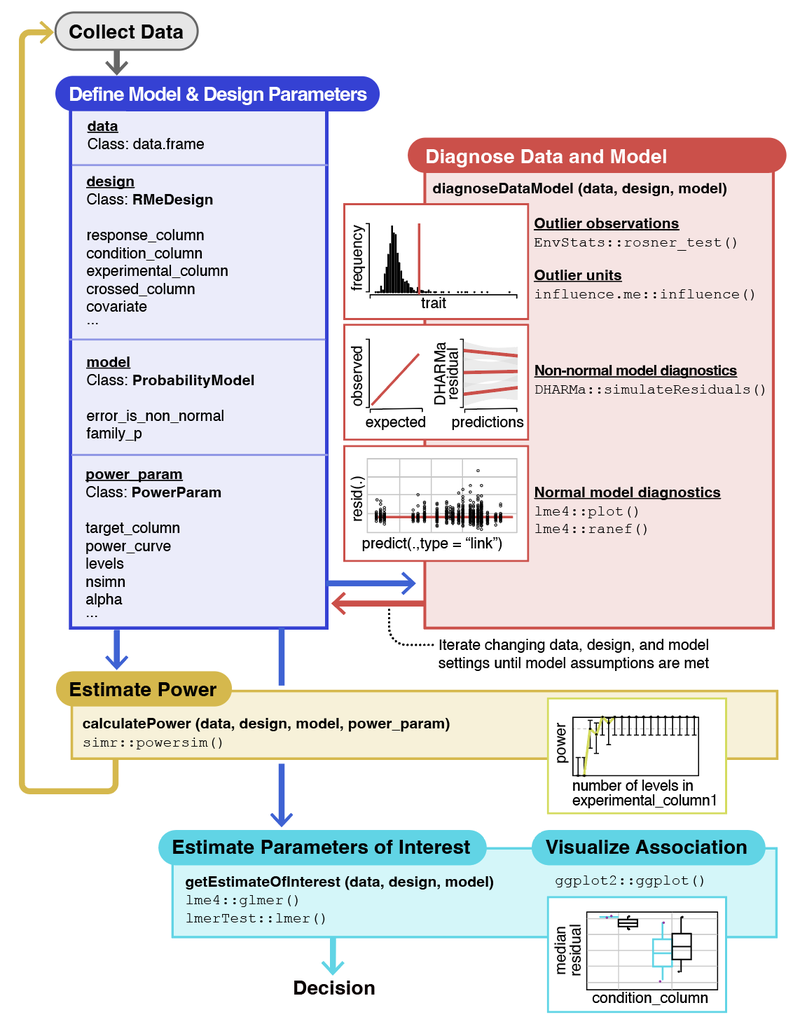

**Figure 1:** Flowchart illustrating the functionality of the package

# 2 Application examples

Here we illustrate the application of RMeDPower2 using data derived from a range of domains in biomedical research.

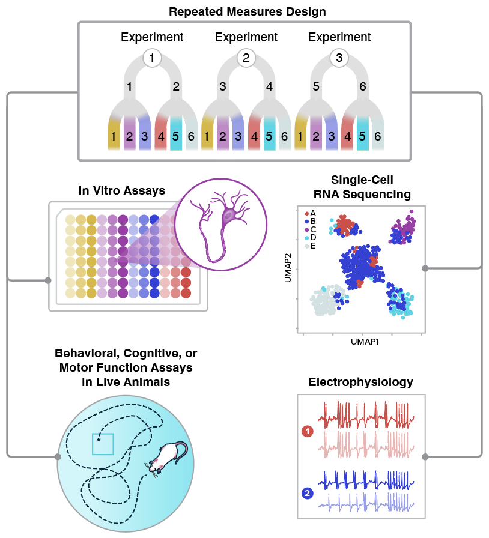

**Figure 2:** Application domains of RMeDPower2: repeated measures designs from in vitro assays, single-cell RNA sequencing, behavioral assays in live animals and electrophysiology

## 2.1 Plate assays

iPSC lines from control and patient derived iPSCs from sALS patients were obtained through the Answer ALS (AALS) consortium36 . AALS is the largest repository of ALS patient samples, and contains publicly available patient-specific iPSCs and multi-OMIC data from motor neurons derived from those iPSCs—including RNA Seq, proteomics and whole genome sequence data— all of which is matched with longitudinal clinical data (https://dataportal.answerals.org/home)36.

We used 6 control lines and 4 sALS lines and differentiated each line into motor neurons (iMNs). iMNs were transduced with a morphology marker and imaged on day ~25 using RM37-45 as previously described36. Images were processed and the soma size of neurons were captured using contour ellipse46 function adapted for use in python (https://www.python.org/).

The next step is to read the data and perform data distribution diagnostics, association analysis, and power simulation.

First, we will read the data from the package and json files with specified parameters:

```r
template_dir <- system.file("input_templates/cell_assay_data", package = "RMeDPower2")
data <- plate_assay_pilot_data
design <- readDesign(file.path(template_dir,"design_cell_assay.json"))
model <- readProbabilityModel(file.path(template_dir,"prob_model.json"))
power_param <- readPowerParams(file.path(template_dir,"power_param.json"))
```

A visualization of the distribution of cell_size2 across experiments and cell-lines as box-plots suggest that the observations in experiment 3 are in general lower than those in the other two experiments.

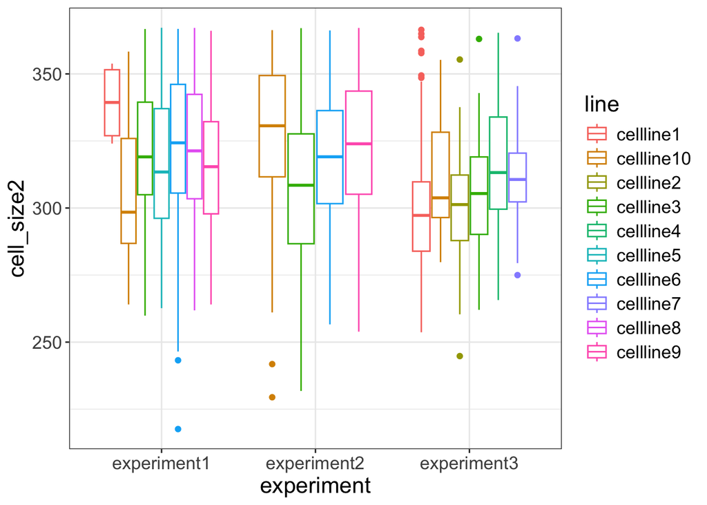

```r
diagnose_res <- diagnoseDataModel(data, design, model)
```

The *diagnoseDataModel* function fits at least one model representing one in the natural scale of the response of interest. Additionally, if individual observations are inferred as outliers using the rosner’s test applied to the residuals of the fitted model then another model is fit without these outlier observations. In addition, if the assumed probability distribution of the residuals of the model is normal then a further additional model are fit using logarithm (log) transformed responses and another one if there are outliers in the log-transformed model fit.

To identify all the models fit to the data

```r
print(diagnose_res$models)
```

```
## [1] "Natural scale"         "Log scale"             "Log scale wo outliers"
```

Let us look the basic QC plots for the models fit in the natural scale of the responses.

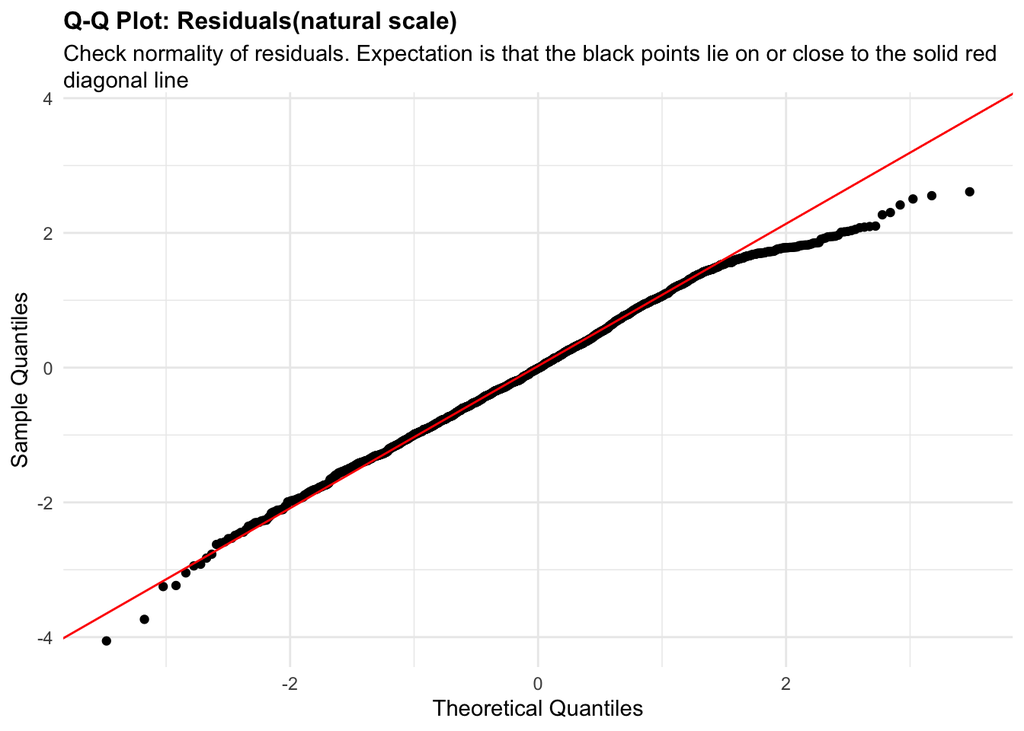

```r
plots <- diagnose_res$diagnostic_plots$natural_scale$plots
captions <- diagnose_res$diagnostic_plots$natural_scale$captions
for (i in seq_along(plots)) {
  print(plots[[i]])
  cat(sprintf("\n\n\n**Figure %d:** %s. %s\n\n", plot_no,names(plots)[i], captions[i]))
  plot_no <- plot_no + 1
}
```

**Figure 3:** residuals_QQ. Check normality of residuals (natural scale). Expectation is that the black points lie on or close to the solid red diagonal line. Check the Normal Q-Q plots for good and bad examples here: https://library.virginia.edu/data/articles/diagnostic-plots

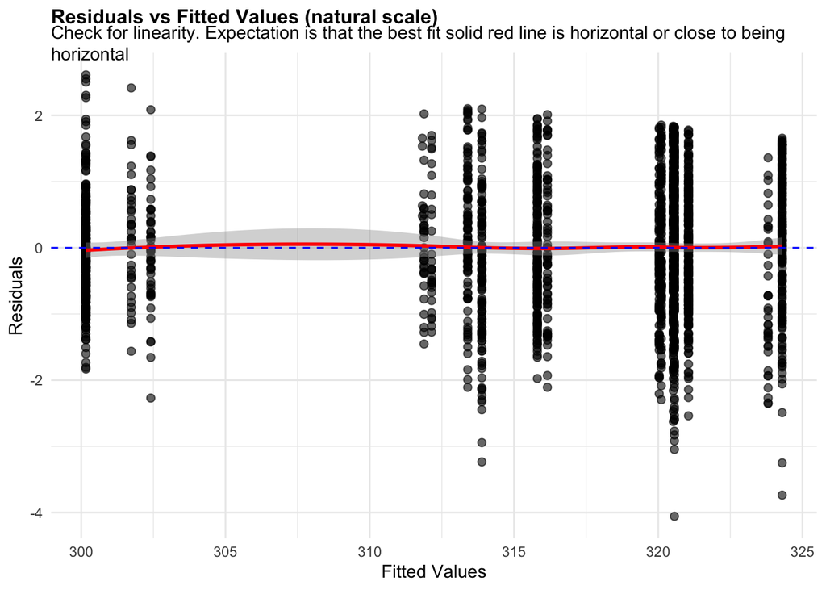

**Figure 4:** residuals_vs_fitted. Check for linearity (natural scale). Expectation is that the best fit solid red line is horizontal or close to being horizontal. Check the Residuals vs Fitted plots for good and bad examples here: https://library.virginia.edu/data/articles/diagnostic-plots

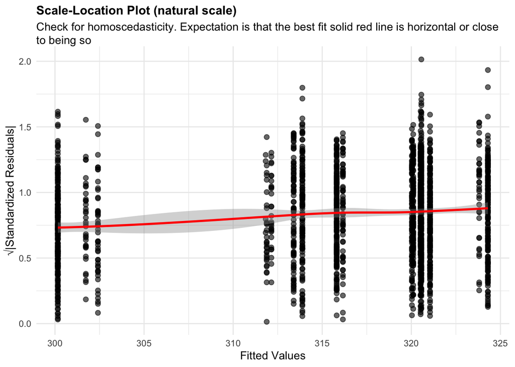

**Figure 5:** residuals_homoscedasticity. Check for homoscedasticity (natural scale). Expectation is that the best fit solid red line is horizontal or close to being so. Check the Scale-Location plots for good and bad examples here: https://library.virginia.edu/data/articles/diagnostic-plots

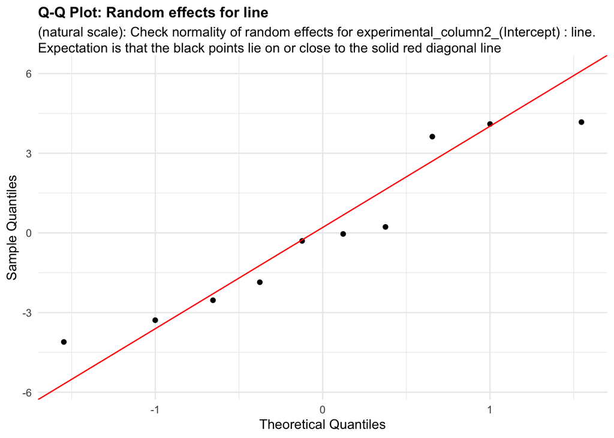

**Figure 6:** random_effects_QQ_1. Check normality of random effects for experimental_column2_(Intercept) (natural scale): line. Expectation is that the black points lie on or close to the solid red diagonal line. Check the Normal Q-Q plots for good and bad examples here: https://library.virginia.edu/data/articles/diagnostic-plots

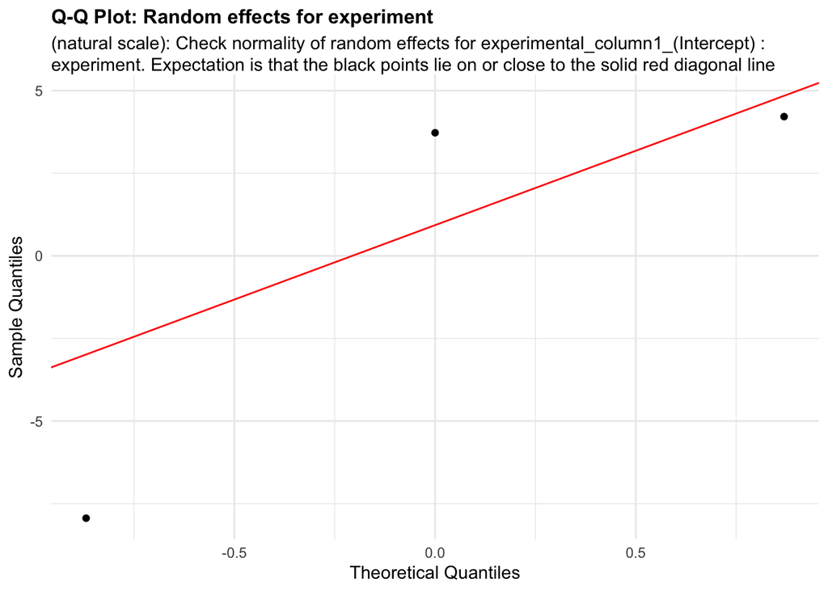

**Figure 7:** random_effects_QQ_2. Check normality of random effects for experimental_column1_(Intercept) (natural scale): experiment. Expectation is that the black points lie on or close to the solid red diagonal line. Check the Normal Q-Q plots for good and bad examples here: https://library.virginia.edu/data/articles/diagnostic-plots

```r
cat("\n\n\n")
```

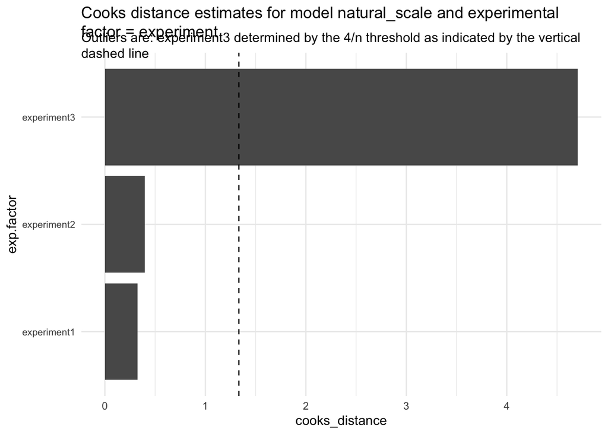

```r
cooks_plots <- diagnose_res$cooks_plots$natural_scale
for(i in 1:length(cooks_plots)) {
  print(cooks_plots[[i]])
  cat(sprintf("\n\n\n**Figure %d:**\n\n", plot_no))
  plot_no <- plot_no + 1
}
```

**Figure 8:**

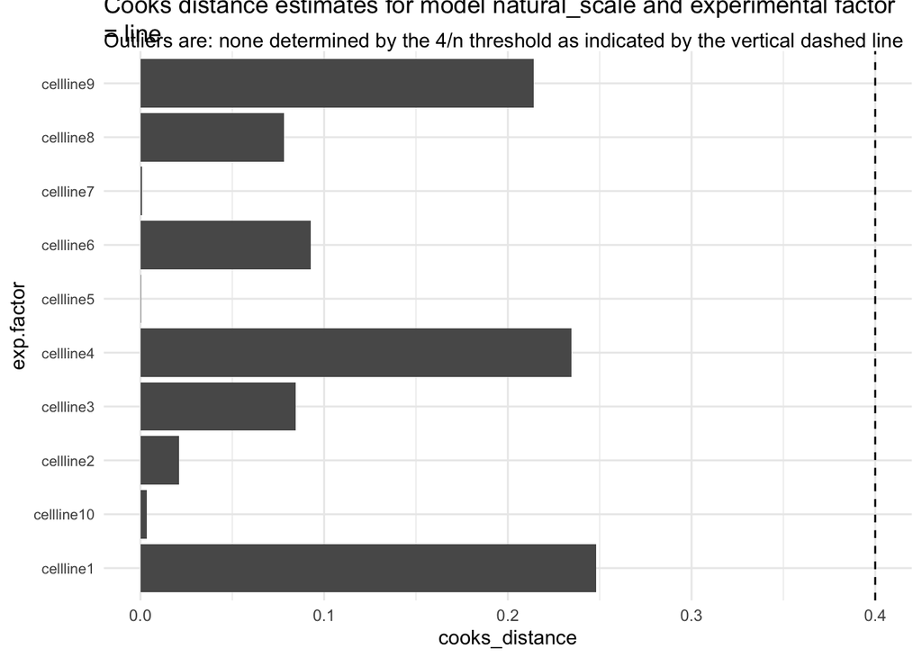

**Figure 9:**

```r
print("Inferred outlier groups are")
```

[1] “Inferred outlier groups are”

```r
print(diagnose_res$inferred_outlier_groups$natural_scale)
```

$experiment [1] “experiment3”

$line [1] “none”

Now, let us look at the same set of QC plots for models on the log-transformed responses.

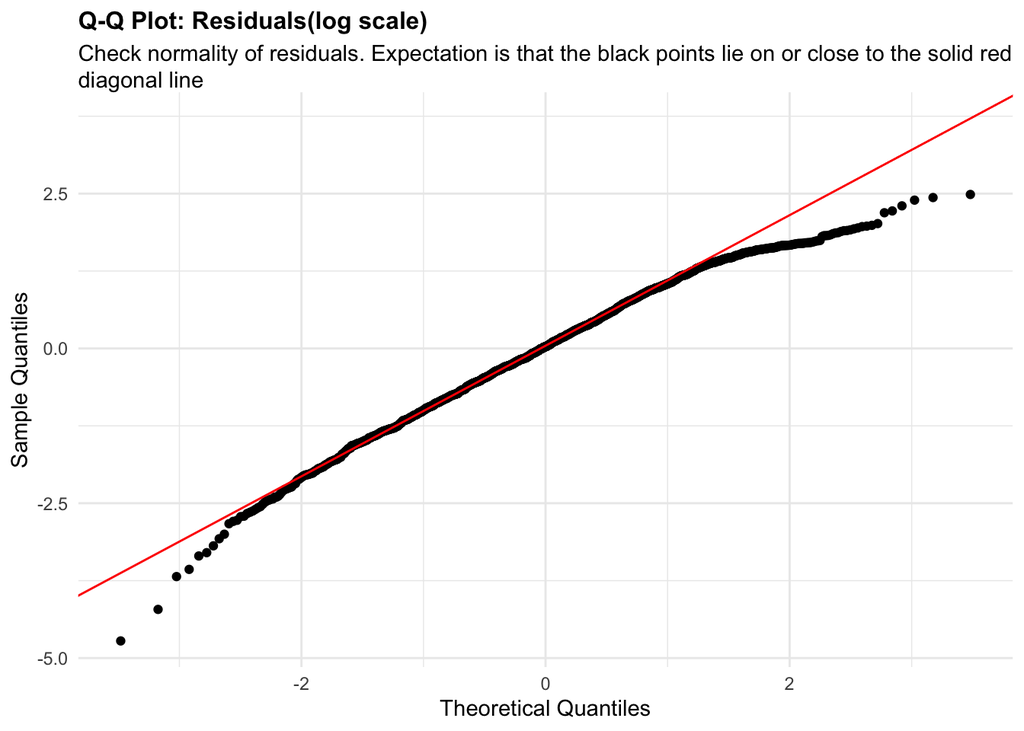

```r
plots <- diagnose_res$diagnostic_plots$log_scale$plots
captions <- diagnose_res$diagnostic_plots$log_scale$captions
for (i in seq_along(plots)) {
  print(plots[[i]])
  cat(sprintf("\n\n\n**Figure %d:** %s. %s\n\n", plot_no,names(plots)[i], captions[i]))
  plot_no <- plot_no + 1
}
```

**Figure 10:** residuals_QQ. Check normality of residuals (log scale). Expectation is that the black points lie on or close to the solid red diagonal line. Check the Normal Q-Q plots for good and bad examples here: https://library.virginia.edu/data/articles/diagnostic-plots

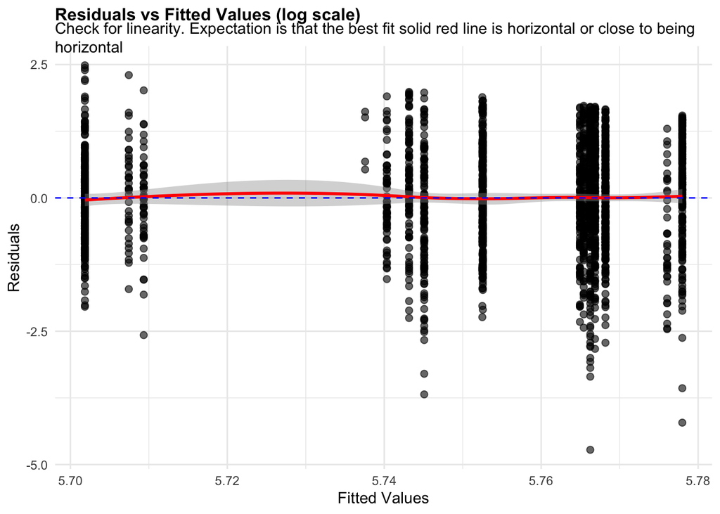

**Figure 11:** residuals_vs_fitted. Check for linearity (log scale). Expectation is that the best fit solid red line is horizontal or close to being horizontal. Check the Residuals vs Fitted plots for good and bad examples here: https://library.virginia.edu/data/articles/diagnostic-plots

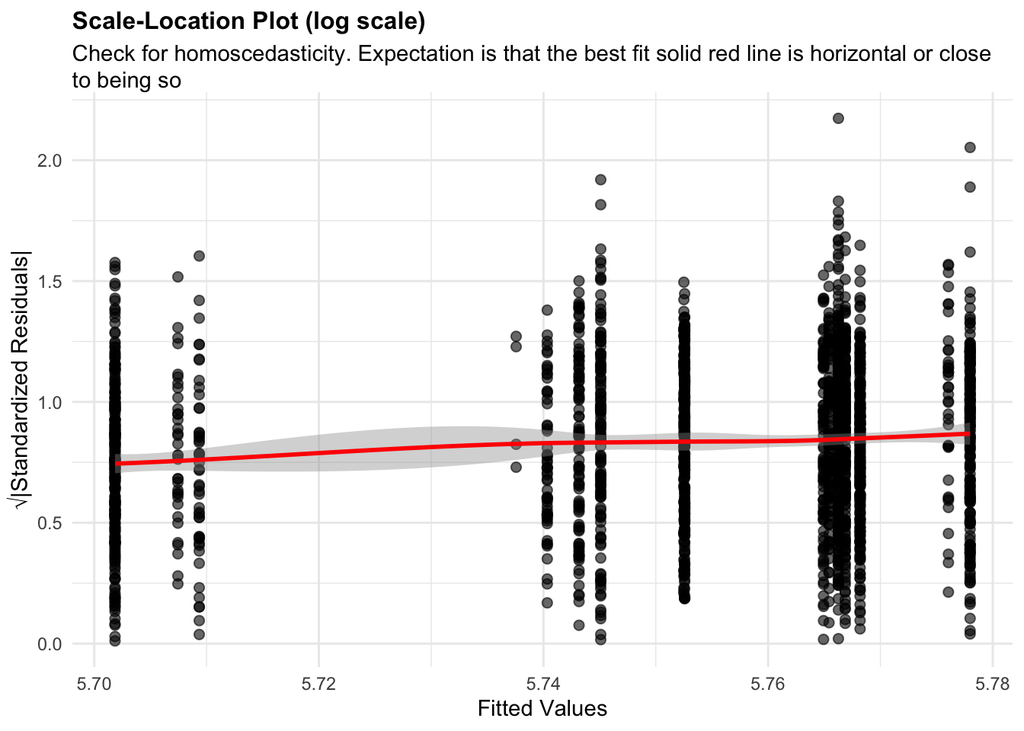

**Figure 12:** residuals_homoscedasticity. Check for homoscedasticity (log scale). Expectation is that the best fit solid red line is horizontal or close to being so. Check the Scale-Location plots for good and bad examples here: https://library.virginia.edu/data/articles/diagnostic-plots

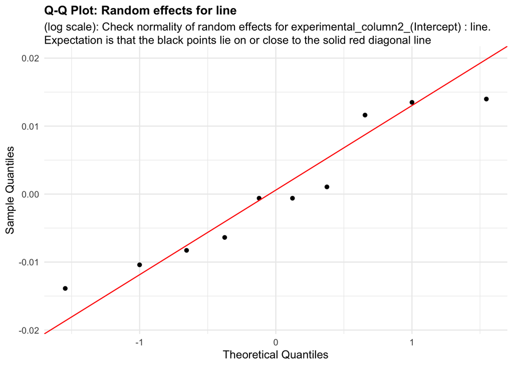

**Figure 13:** random_effects_QQ_1. Check normality of random effects for experimental_column2_(Intercept) (log scale): line. Expectation is that the black points lie on or close to the solid red diagonal line. Check the Normal Q-Q plots for good and bad examples here: https://library.virginia.edu/data/articles/diagnostic-plots

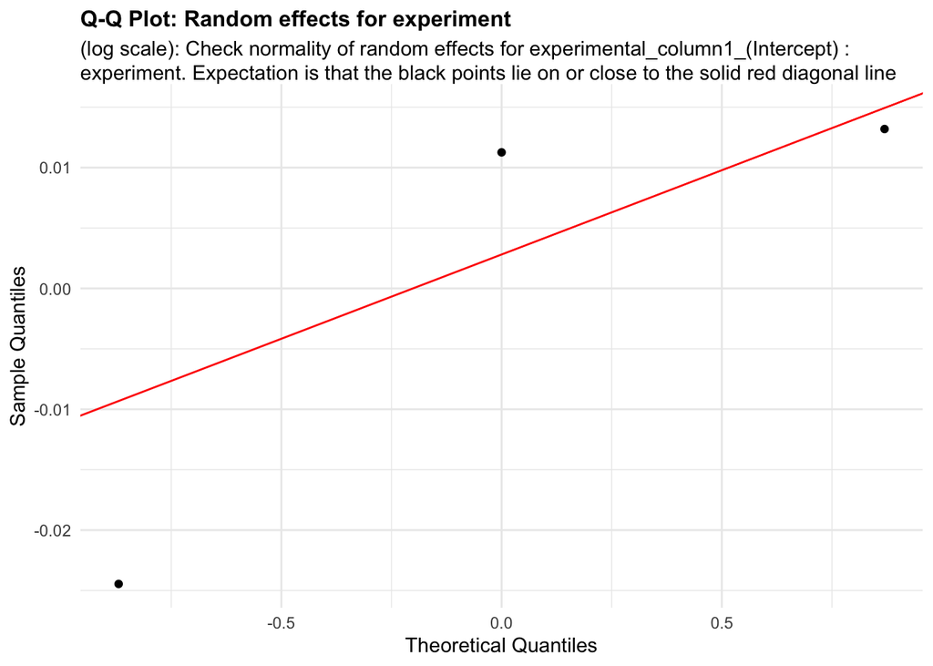

**Figure 14:** random_effects_QQ_2. Check normality of random effects for experimental_column1_(Intercept) (log scale): experiment. Expectation is that the black points lie on or close to the solid red diagonal line. Check the Normal Q-Q plots for good and bad examples here: https://library.virginia.edu/data/articles/diagnostic-plots

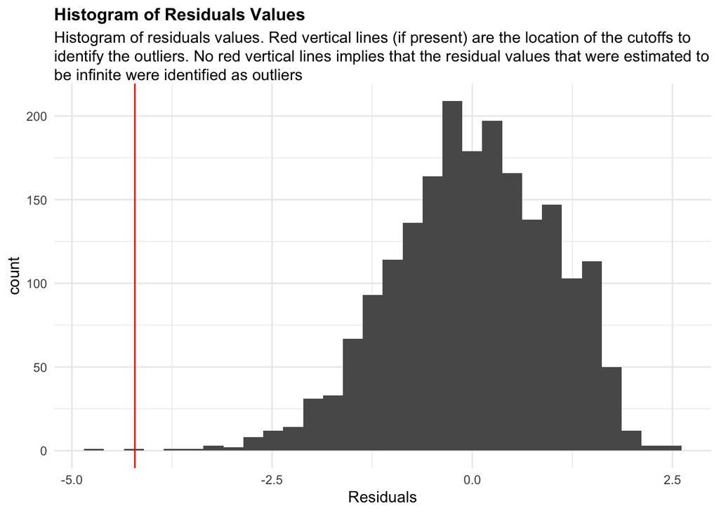

**Figure 15:** residuals_histogram. Histogram of residuals values. Red vertical lines (if present) are the location of the cutoffs to identify the outliers. No red vertical lines implies that the residual values that were estimated to be infinite were identified as outliers

```r
cooks_plots <- diagnose_res$cooks_plots$log_scale

cat("\n\n\n")
```

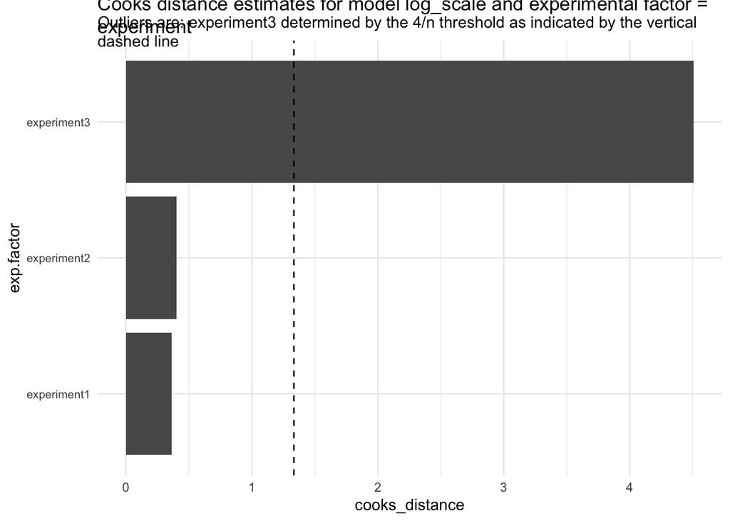

```r
for(i in 1:length(cooks_plots)) {
  print(cooks_plots[[i]])
  cat(sprintf("\n\n\n**Figure %d:**\n\n", plot_no))
  plot_no <- plot_no + 1
}
```

**Figure 16:**

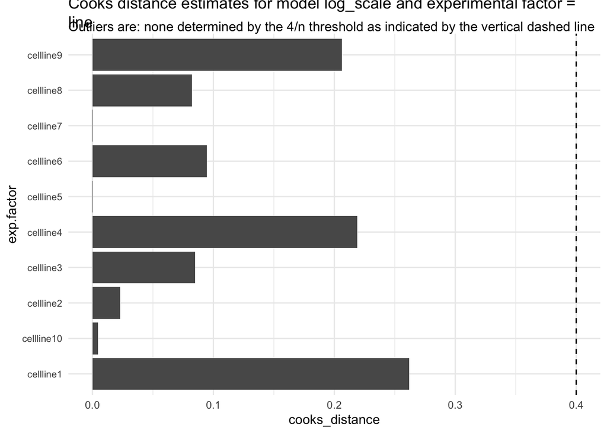

**Figure 17:**

```r
print("Inferred outlier groups are")
```

[1] “Inferred outlier groups are”

```r
print(diagnose_res$inferred_outlier_groups$natural_scale)
```

$experiment [1] “experiment3”

$line [1] “none”

We see normality assumption is better met with the log-transformed model (Figure 10) compared to the model in the natural scale (Figure 3). The reasonably horizontal best fit lines for the residuals from the log-transformed model versus the fitted values (Figure 11), and the square-root of the absolute values of the residuals versus the fitted values (Figure 12), suggest both the LMM model assumptions of linearity and homoscedasticity are reasonable.

The code also outputs Cook’s distance measures for each experiment and cell-line that is intended to capture how influential each of these were in determining the final parameter estimates in the LMM model.

We will use the log transformed cell_size2 data for parameter estimation using the following commands.

```r
design_update <- design
data_update <- diagnose_res$Data_updated
print(colnames(data_update))
```

```
##  [1] "cell_size2_logTransformed_noOutlier" "cell_size2_logTransformed"
##  [3] "experiment"                          "line"
##  [5] "classification"                      "cell_size1"
##  [7] "cell_size2"                          "cell_size3"
##  [9] "cell_size4"                          "cell_size5"
## [11] "cell_size6"
```

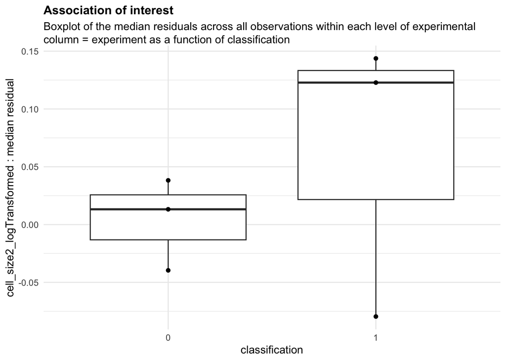

```r
design_update@response_column <-  "cell_size2_logTransformed"
estimate_res <- getEstimatesOfInterest(data_update, design_update, model,print_plots = FALSE)
```

**Figure 18:**

The median residual boxplot shows the differences in the distribution of the response variable for the two conditions.

```r
##print model summary output
print(estimate_res[[1]])
```

```
## Linear mixed model fit by REML. t-tests use Satterthwaite's method [
## lmerModLmerTest]
## Formula: response_column ~ condition_column + (1 | experimental_column1) +
##     (1 | experimental_column2)
##    Data: data.update
##
## REML criterion at convergence: -4365.2
##
## Scaled residuals:
##     Min      1Q  Median      3Q     Max
## -3.7195 -0.6746  0.0266  0.7599  2.5113
##
## Random effects:
##  Groups               Name        Variance  Std.Dev.
##  experimental_column2 (Intercept) 0.0001602 0.01266
##  experimental_column1 (Intercept) 0.0004883 0.02210
##  Residual                         0.0064730 0.08045
## Number of obs: 1999, groups:  experimental_column2, 10; experimental_column1, 3
##
## Fixed effects:
##                   Estimate Std. Error       df t value Pr(>|t|)
## (Intercept)       5.740140   0.014085 2.576712  407.55 2.88e-07 ***
## condition_column1 0.026001   0.009456 7.860567    2.75   0.0255 *
## ---
## Signif. codes:  0 '***' 0.001 '**' 0.01 '*' 0.05 '.' 0.1 ' ' 1
##
## Correlation of Fixed Effects:
##             (Intr)
## cndtn_clmn1 -0.269
```

As a result of linear mixed model-based association analysis, the response variable was found to be significantly associated with the condition variable with an estimate of 0.03.

We can also estimate the statistical needed to estimate the observed differences in mean perimeter across 15 experimental batches

```r
power_param@max_size <- 15
power_res <- calculatePower(data_update, design_update, model, power_param)
```

[[1]]

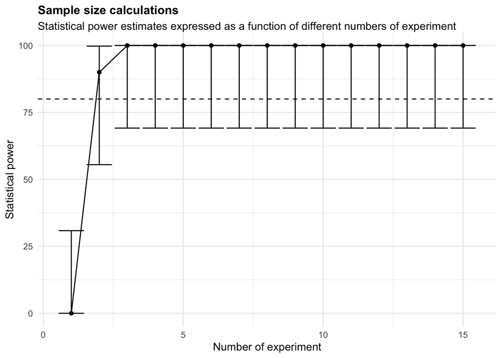

**Figure 19:**

```r
full_data <- plate_assay_full_data

design@response_column <- "perim_2th_effect"
design@condition_column <- "classif"
full_diag_res <- diagnoseDataModel(full_data, design, model)
full_data_update <- full_diag_res$Data_updated
full_design <- design
full_design@response_column <- "perim_2th_effect_logTransformed"
```

Note now, none of the experimental batches or the 13 cell-lines are considered outliers or unduly influencing the final parameter estimates.

```r
cooks_plots <- full_diag_res$cooks_plots$log_scale
cat("\n\n\n")
```

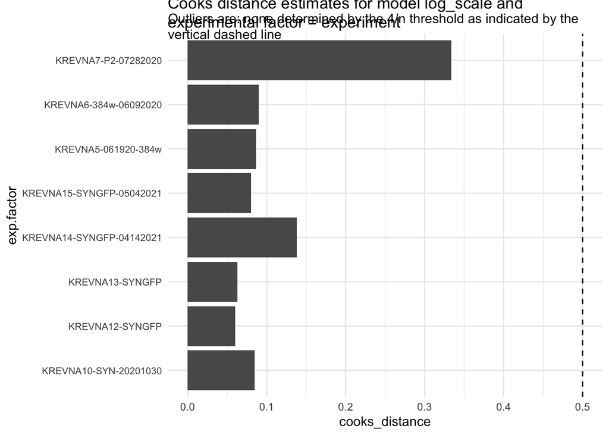

```r
for(i in 1:length(cooks_plots)) {
  print(cooks_plots[[i]])
  cat(sprintf("\n\n\n**Figure %d:**\n\n", plot_no))
  plot_no <- plot_no + 1
}
```

**Figure 20:**

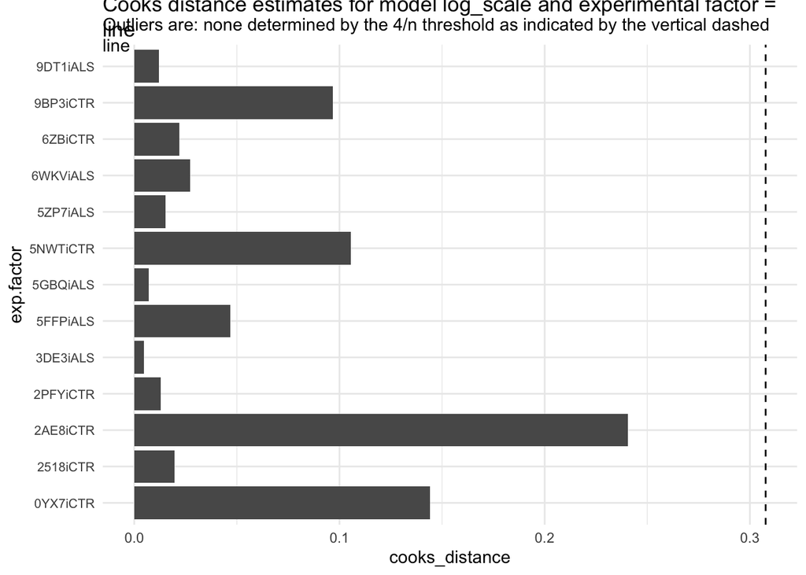

**Figure 21:**

```r
print("Inferred outlier groups are")
```

[1] “Inferred outlier groups are”

```r
print(diagnose_res$inferred_outlier_groups$natural_scale)
```

$experiment [1] “experiment3”

$line [1] “none”

We derive an estimate of 0.027 as the mean difference in perimeter with an associated significance of 0.006 using the data from 8 experimental batches.

```
## Linear mixed model fit by REML. t-tests use Satterthwaite's method [
## lmerModLmerTest]
## Formula: response_column ~ condition_column + (1 | experimental_column1) +
##     (1 | experimental_column2)
##    Data: data.update
##
## REML criterion at convergence: -10215.6
##
## Scaled residuals:
##     Min      1Q  Median      3Q     Max
## -4.1653 -0.6837 -0.0505  0.6413  3.0906
##
## Random effects:
##  Groups               Name        Variance Std.Dev.
##  experimental_column2 (Intercept) 0.000168 0.01296
##  experimental_column1 (Intercept) 0.000883 0.02971
##  Residual                         0.010516 0.10255
## Number of obs: 5989, groups:  experimental_column2, 13; experimental_column1, 8
##
## Fixed effects:
##                    Estimate Std. Error        df t value Pr(>|t|)
## (Intercept)        5.753966   0.011811 10.213598 487.158   <2e-16 ***
## condition_column1  0.027159   0.007924 10.925415   3.427   0.0057 **
## ---
## Signif. codes:  0 '***' 0.001 '**' 0.01 '*' 0.05 '.' 0.1 ' ' 1
##
## Correlation of Fixed Effects:
##             (Intr)
## cndtn_clmn1 -0.309
```

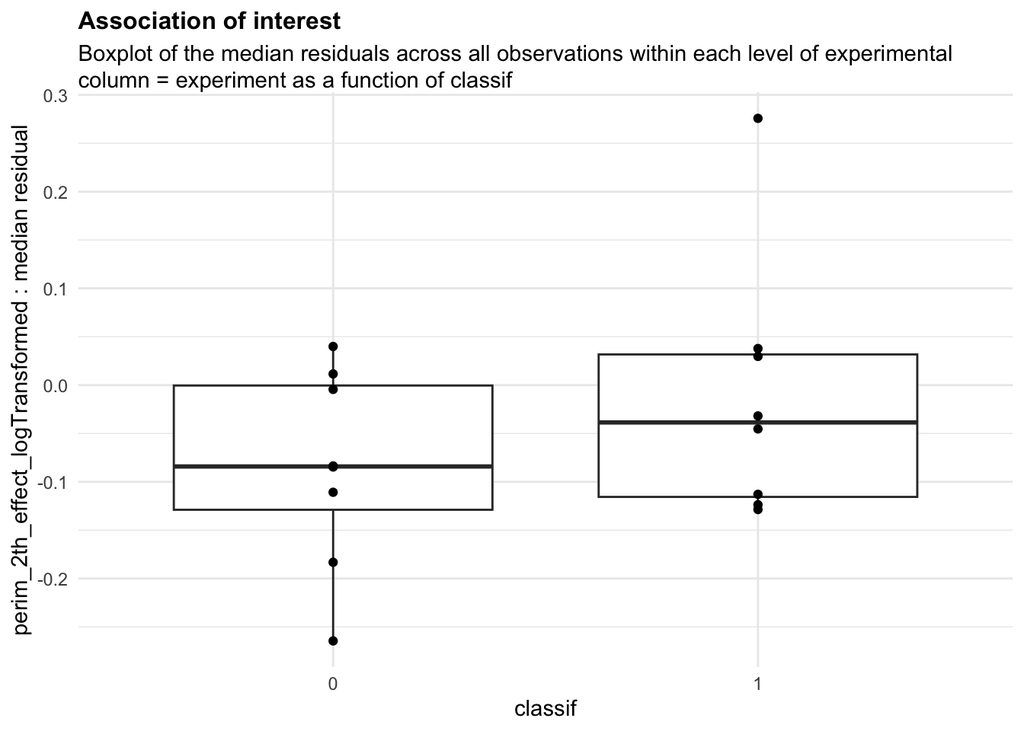

```r
full_res <- getEstimatesOfInterest(full_data_update, full_design, model, print_plots = FALSE)
print(full_res[[1]])
```

**Figure 22:**

## 2.2 Single-cell RNA-seq assays

Here we will use data derived from the single-nuclei RNA-seq experiments performed in Koutsodendris et al[]. paper One of the goals in these experiments was to assess the effect of the APOE gene isoform on brain pathology in a mouse model of Alzheimer’s Disease (AD). Specifically, the *APOE4* haplotype is a known risk factor for AD compared to those with the *APOE3* gene isoform. Koutsodendris et a., investigates the role of expression of neuronal *APOE4* expression in the development of disease pathology in the *APOE4* knock-in mouse model. The scRNA seq dataset consists of over 1000 cells derived from the hippocampus brain region across 4 mice harboring the human *APOE4* gene knocked-in the mouse *Apoe* locus and 4 other mice (called E4-KI-Syn1-Cre) with the human *APOE4* gene also knocked-in in the same mouse. However, the *APOE4* expression in these mice is knocked out specifically in the neurons. The single cell data allowed the identification of multiple clusters or cell-types including cluster 7 representing a group of excitatory neurons.

### 2.2.1 Cell-type/cluster associations

One typical use of scRNA seq data is clustering analysis. First, we can ask whether the proportion of nuclei derived from APOE4-KI mice differs from the proportion of nuclei derived from APOE4-KI-Syn1-Cre mice in cluster 7. We want to examine the proportion of cells in each mouse assigned cluster 7 by testing whether there were differences in the log odds of cluster membership in cluster 7 between APOE4-KI mice and APOE4-KI-Syn1-Cre. The data consists of the number of nuclei per animal present in the cluster and also the total number of nuclei that were isolated from this animal.

#### 2.2.1.1 Associations with genotype

The following commands load data and set parameters to specify the experimental design, distribution information, and power simulation conditions.

The first few lines of data display cell meta information.

```r
template_dir <- system.file("input_templates/single_cell_data/celltype_genotype", package = "RMeDPower2")
data <- snRNAseq_cluster_count_data
head(data)
```

```
##   sample_id      animal_model total_numbers_of_cells_per_sample cluster_id
## 1       S10          PS19-fE4                              6552          7
## 2       S11          PS19-fE4                              6214          7
## 3       S12 PS19-fE4 Syn1-Cre                              7873          7
## 4       S13 PS19-fE4 Syn1-Cre                              6577          7
## 5        S4          PS19-fE4                             16223          7
## 6        S5          PS19-fE4                             12357          7
##   number_of_cells_per_sample_in_cluster          Genotype Mouse_. Sex PS19 Cre
## 1                                   263          PS19-fE4     154   F    +   -
## 2                                     8          PS19-fE4     413   M    +   -
## 3                                    58 PS19-fE4_Syn1-Cre     305   M    + +_-
## 4                                     1 PS19-fE4_Syn1-Cre     504   F    + +_-
## 5                                  2139          PS19-fE4     129   F    +   -
## 6                                  1811          PS19-fE4     156   M    +   -
##   ApoE      DOB Age_Perfused Date_Perfused Date_of_Nuc_Isolation
```

[output cut: 27 more lines]

The following command reads parameters from json files and print corresponding objects, allowing us to check which parameters have been assigned.

```r
##load the design
design <- readDesign(file.path(template_dir, "design_celltype.json"))
print(design)
```

```
## An object of class "RMeDesign"
## Slot "response_column":
## [1] "number_of_cells_per_sample_in_cluster"
##
## Slot "covariate":
## [1] "Sex"
##
## Slot "condition_column":
## [1] "Genotype"
##
## Slot "condition_is_categorical":
## [1] TRUE
##
## Slot "experimental_columns":
## [1] "sample_id"
##
## Slot "crossed_columns":
## NULL
##
## Slot "total_column":
## [1] "total_numbers_of_cells_per_sample"
##
## Slot "outlier_alpha":
## [1] 0.05
##
## Slot "na_action":
## [1] "complete"
##
## Slot "include_interaction":
## [1] FALSE
##
## Slot "random_slope_variable":
## NULL
##
## Slot "covariate_is_categorical":
## [1] TRUE
```

```r
##load the probability model
model <- readProbabilityModel(file.path(template_dir, "prob_model.json"))
print(model)
```

```
## An object of class "ProbabilityModel"
## Slot "error_is_non_normal":
## [1] TRUE
##
## Slot "family_p":
## [1] "binomial"
```

```r
##load the relevant power parameters
power_param <- readPowerParams(file.path(template_dir, "power_param.json"))
print(power_param)
```

```
## An object of class "PowerParams"
## Slot "target_columns":
## [1] "sample_id"
##
## Slot "power_curve":
## [1] 1
##
## Slot "nsimn":
## [1] 10
##
## Slot "levels":
## [1] 1
##
## Slot "max_size":
## [1] 1
##
## Slot "alpha":
## [1] 0.05
##
## Slot "breaks":
## NULL
##
## Slot "effect_size":
## NULL
##
## Slot "icc":
## NULL
```

Now let’s use the ‘diagnoseDataModel’ function to diagnose the data quality and distributional assumptions of the model.

```r
diagnose_res <- diagnoseDataModel(data, design, model)
```

```r
print(diagnose_res$models)
```

```
## [1] "Natural scale"
```

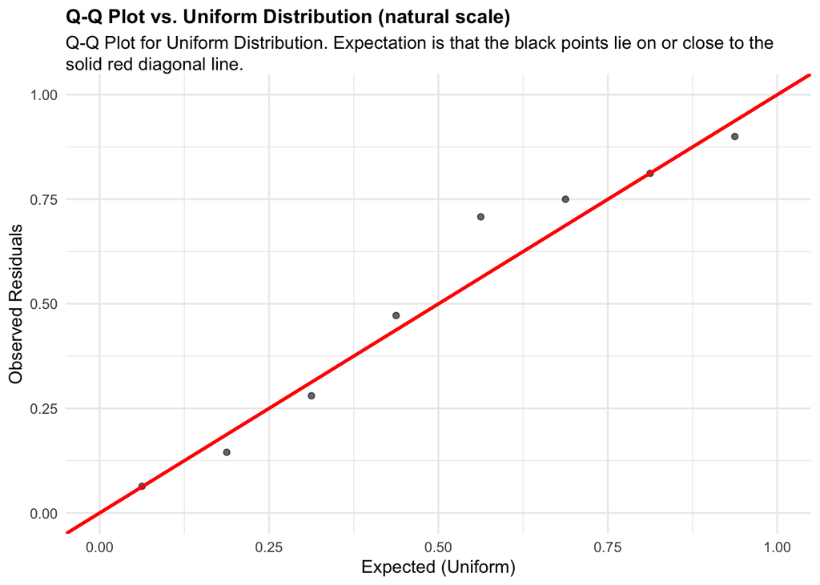

```r
plots <- diagnose_res$diagnostic_plots$natural_scale$plots
captions <- diagnose_res$diagnostic_plots$natural_scale$captions
for (i in seq_along(plots)) {
  print(plots[[i]])
    cat(sprintf("\n\n\n**Figure %d:** %s. %s\n\n", plot_no,names(plots)[i], captions[i]))
  plot_no <- plot_no + 1
}
```

**Figure 23:** residuals_QQ. Q-Q Plot for Uniform Distribution. Expectation is that the black points lie on or close to the solid red diagonal line. Check the Q-Q plots for good and bad examples here: https://library.virginia.edu/data/articles/diagnostic-plots

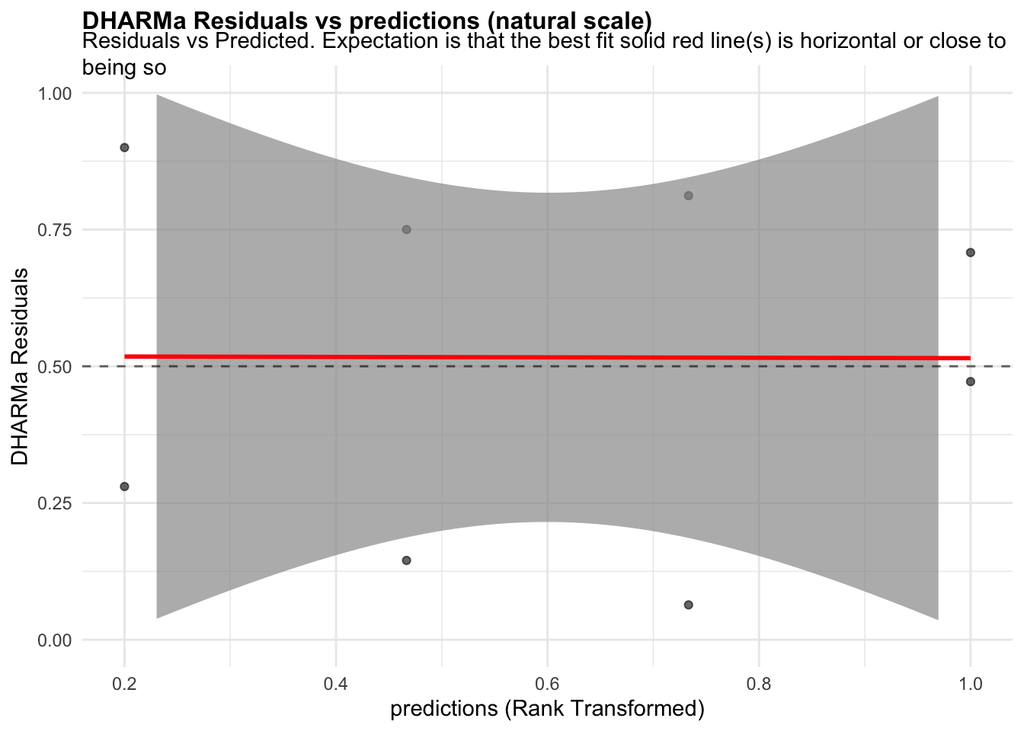

**Figure 24:** residuals_vs_predicted. Residuals vs Predicted Check the Residuals vs Fitted plots for good and bad examples here: https://library.virginia.edu/data/articles/diagnostic-plots

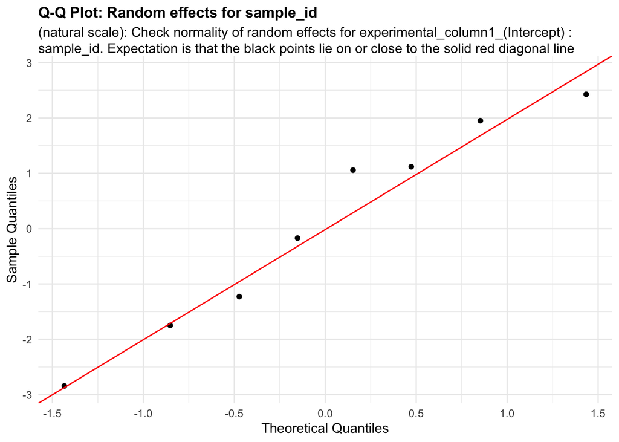

**Figure 25:** random_effects_QQ_1. Check normality of random effects for experimental_column1_(Intercept) (natural scale): sample_id. Expectation is that the black points lie on or close to the solid red diagonal line. Check the Normal Q-Q plots for good and bad examples here: https://library.virginia.edu/data/articles/diagnostic-plots

```r
cooks_plots <- diagnose_res$cooks_plots$natural_scale
cat("\n\n\n")
```

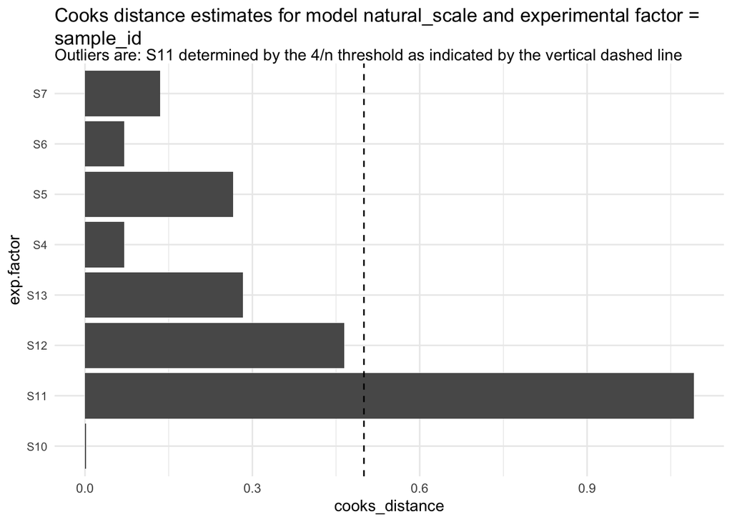

```r
for(i in 1:length(cooks_plots)) {
  print(cooks_plots[[i]])
  cat(sprintf("\n\n\n**Figure %d:**\n\n", plot_no))
  plot_no <- plot_no + 1
}
```

**Figure 26:**

```r
print("Inferred outlier groups are")
```

[1] “Inferred outlier groups are”

```r
print(diagnose_res$inferred_outlier_groups$natural_scale)
```

$sample_id [1] “S11”

We can now estimate differences in the log odds of cluster membership in cluster 7 between APOE4-KI mice and APOE4-KI-Syn1-Cre using the function ‘getEstimatesOfInterest’.

```
## Generalized linear mixed model fit by maximum likelihood (Laplace
##   Approximation) [glmerMod]
##  Family: binomial  ( logit )
## Formula:
## cbind(response_column, (total_column - response_column)) ~ condition_column +
##     covariate + (1 | experimental_column1)
##    Data: data.update
##
##       AIC       BIC    logLik -2*log(L)  df.resid
##     100.9     101.2     -46.4      92.9         4
##
## Scaled residuals:
##      Min       1Q   Median       3Q      Max
## -0.41163 -0.28356  0.00219  0.02755  0.09292
##
## Random effects:
##  Groups               Name        Variance Std.Dev.
##  experimental_column1 (Intercept) 3.464    1.861
## Number of obs: 8, groups:  experimental_column1, 8
##
## Fixed effects:
##                                   Estimate Std. Error z value Pr(>|z|)
## (Intercept)                        -3.0030     1.1493  -2.613  0.00898 **
## condition_columnPS19-fE4_Syn1-Cre  -3.6302     1.3514  -2.686  0.00723 **
## covariateM                         -0.7104     1.3482  -0.527  0.59823
## ---
## Signif. codes:  0 '***' 0.001 '**' 0.01 '*' 0.05 '.' 0.1 ' ' 1
##
## Correlation of Fixed Effects:
##             (Intr) c_PS19
## c_PS19-E4_S -0.560
## covariateM  -0.582 -0.003
```

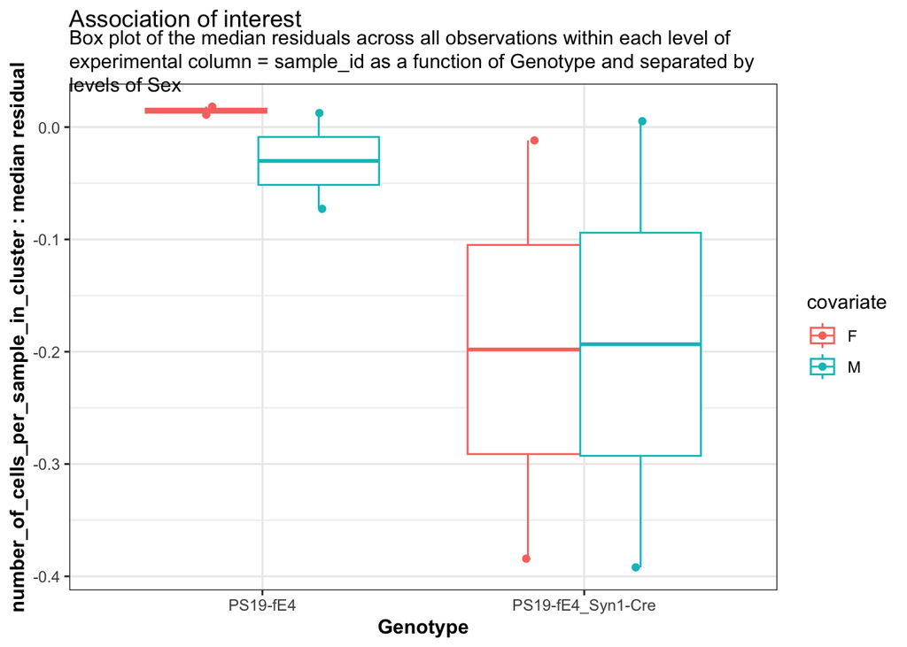

```r
estimate_res <- getEstimatesOfInterest(data, design, model, print_plots = F)
print(estimate_res[[1]])
```

**Figure 27:**

And estimate whether or not statistical power we have to estimate the given observed association with varying number of mice per group.

```r
print(power_param@target_columns)
```

```
## [1] "sample_id"
```

```r
power_res <- calculatePower(data, design, model, power_param)
```

[[1]]

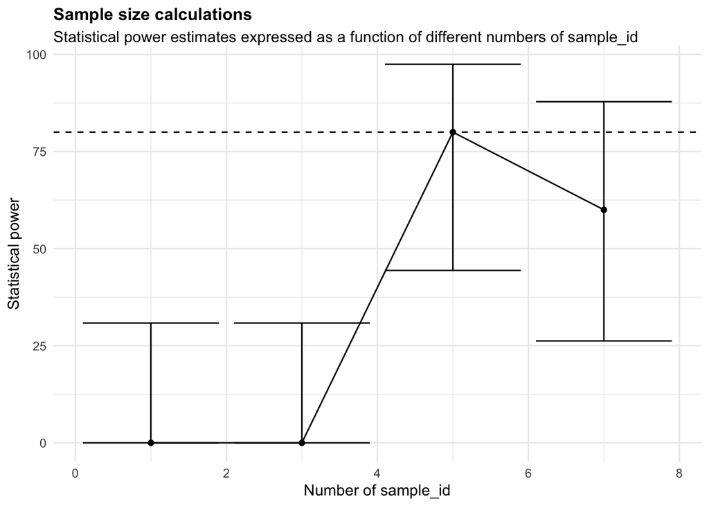

**Figure 28:**

```r
design@include_interaction <- TRUE
```

The estimates after including the interaction term could be recovered by,

```
## Generalized linear mixed model fit by maximum likelihood (Laplace
##   Approximation) [glmerMod]
##  Family: binomial  ( logit )
## Formula:
## cbind(response_column, (total_column - response_column)) ~ condition_column *
##     covariate + (1 | experimental_column1)
##    Data: data.update
##
##       AIC       BIC    logLik -2*log(L)  df.resid
##     102.3     102.7     -46.2      92.3         3
##
## Scaled residuals:
##      Min       1Q   Median       3Q      Max
## -0.42015 -0.27409 -0.00398  0.03400  0.10782
##
## Random effects:
##  Groups               Name        Variance Std.Dev.
##  experimental_column1 (Intercept) 3.202    1.789
## Number of obs: 8, groups:  experimental_column1, 8
##
## Fixed effects:
##                                              Estimate Std. Error z value
## (Intercept)                                    -2.530      1.266  -1.999
## condition_columnPS19-fE4_Syn1-Cre              -4.615      1.838  -2.511
## covariateM                                     -1.660      1.798  -0.923
## condition_columnPS19-fE4_Syn1-Cre:covariateM    2.003      2.598   0.771
##                                              Pr(>|z|)
## (Intercept)                                    0.0456 *
## condition_columnPS19-fE4_Syn1-Cre              0.0120 *
## covariateM                                     0.3558
## condition_columnPS19-fE4_Syn1-Cre:covariateM   0.4406
## ---
## Signif. codes:  0 '***' 0.001 '**' 0.01 '*' 0.05 '.' 0.1 ' ' 1
##
## Correlation of Fixed Effects:
##                 (Intr) cn_PS19-E4_S1-C covrtM
## cn_PS19-E4_S1-C -0.689
## covariateM      -0.704  0.486
## c_PS19-E4_S1-C:  0.487 -0.706          -0.692
```

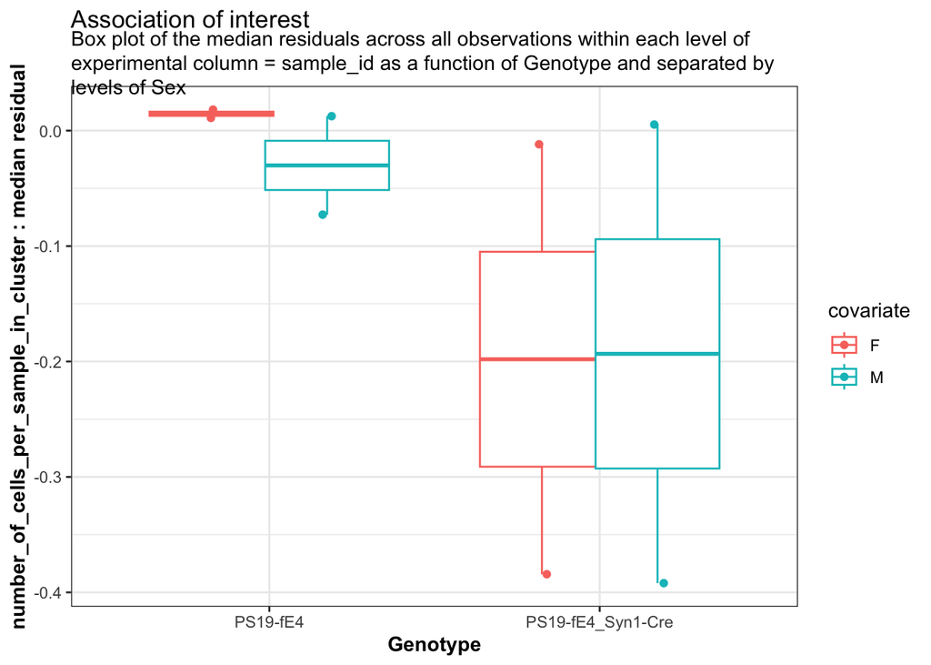

```r
estimate_res_w_interaction <- getEstimatesOfInterest(data, design, model,print_plots = F)
print(estimate_res_w_interaction[[1]])
```